# Pregnancy Detection with Machine Learning

Chao Cheng | `chaozcheng.com` | April 2018

## Introduction

This notebook contains the results of my Pregnancy Detection project, which is based on the traditional Chinese medicinal practice of observing pregnancies through wrist palpations. Using data from women at a women and children's hospital, two different approaches are used to construct a predictive model, the first being a classical machine learning pipeline, and the second being a deep learning technique known as Recurrent Neural Networks (RNNs).

I began this project during the summer of 2017.

## Part One: Classical Machine Learning

In this first section, I use some common machine learning algorithms utilizing 10-fold cross validation in order to obtain a general model, in addition to taking a closer look at the data.

### 1) Data exploration

```python
import numpy as np
                    import pandas as pd
                    import seaborn as sns
                    import matplotlib.pyplot as plt
                    %matplotlib inline
```

```python
# import data
                    data1 = pd.read_csv('/Users/Chao/Desktop/Pulse/data.csv')
```

```python
data1.shape
```

```
(550, 19)
```

```python
data1.info()
```

```
<class 'pandas.core.frame.DataFrame'>
                        RangeIndex: 550 entries, 0 to 549
                        Data columns (total 19 columns):
                        Num         550 non-null object
                        t1          550 non-null float64
                        t2          550 non-null float64
                        t4          550 non-null float64
                        t5          550 non-null float64
                        t           550 non-null float64
                        w           550 non-null float64
                        h1          550 non-null float64
                        h3          550 non-null float64
                        h4          550 non-null float64
                        h5          550 non-null float64
                        alpha       550 non-null float64
                        theta       550 non-null float64
                        Aa          550 non-null float64
                        Ab          550 non-null float64
                        pulse       550 non-null int64
                        source      550 non-null int64
                        pressure    550 non-null float64
                        output      550 non-null int64
                        dtypes: float64(15), int64(3), object(1)
                        memory usage: 81.7+ KB
```

```python
list(data1.columns.values)
```

```
['Num',
                        't1',
                        't2',
                        't4',
                        't5',
                        't',
                        'w',
                        'h1',
                        'h3',
                        'h4',
                        'h5',
                        'alpha',
                        'theta',
                        'Aa',
                        'Ab',
                        'pulse',
                        'source',
                        'pressure',
                        'output']
```

```python
# check any NA in the dataset
                        data1.isnull().any()
```

```
Num         False
                            t1          False
                            t2          False
                            t4          False
                            t5          False
                            t           False
                            w           False
                            h1          False
                            h3          False
                            h4          False
                            h5          False
                            alpha       False
                            theta       False
                            Aa          False
                            Ab          False
                            pulse       False
                            source      False
                            pressure    False
                            output      False
                            dtype: bool
```

```python
data1.head(10)
```

|  | Num | t1 | t2 | t4 | t5 | t | w | h1 | h3 | h4 | h5 | alpha | theta | Aa | Ab | pulse | source | pressure | output |
| --- | --- | --- | --- | --- | --- | --- | --- | --- | --- | --- | --- | --- | --- | --- | --- | --- | --- | --- | --- |
| 0 | 515016 | 0.180000 | 0.320000 | 0.460000 | 0.250000 | 0.655000 | 0.180000 | 7.195312 | 4.131000 | 2.951625 | 0.297375 | 57.262653 | 86.247510 | 14.600109 | 48.808359 | 86 | 180 | 7.195312 | 0 |
| 1 | 515017 | 0.145000 | 0.268333 | 0.400000 | 0.401667 | 0.778333 | 0.231667 | 5.072938 | 3.873187 | 2.085313 | 0.106688 | 54.658850 | 113.863681 | 10.124750 | 35.765609 | 79 | 180 | 5.072938 | 0 |
| 2 | 515019 | 0.120000 | 0.236667 | 0.360000 | 0.446667 | 0.806667 | 0.220000 | 14.848250 | 11.402250 | 7.423750 | 0.121875 | 78.568711 | 55.805781 | 22.146719 | 113.487688 | 71 | 180 | 14.848250 | 0 |
| 3 | 515020 | 0.115000 | 0.245000 | 0.385000 | 0.385000 | 0.725000 | 0.265000 | 7.991812 | 6.217500 | 3.564750 | 0.931500 | 70.459684 | 93.796533 | 14.279391 | 81.033797 | 85 | 160 | 7.991812 | 0 |
| 4 | 515026 | 0.106000 | 0.230000 | 0.360000 | 0.274000 | 0.636000 | 0.166000 | 7.828425 | 4.975650 | 2.260725 | 0.308100 | 71.228240 | 72.404355 | 9.454012 | 40.078069 | 93 | 160 | 7.828425 | 0 |
| 5 | 515028 | 0.140000 | 0.230000 | 0.326667 | 0.370000 | 0.686667 | 0.193333 | 14.679625 | 11.587000 | 6.243625 | 0.366500 | 76.595034 | 51.998686 | 27.539562 | 85.191063 | 91 | 180 | 14.679625 | 0 |
| 6 | 515030 | 0.093571 | 0.196429 | 0.304286 | 0.385714 | 0.690000 | 0.160000 | 13.224161 | 9.056411 | 4.649116 | 0.292607 | 79.958726 | 47.318490 | 14.818379 | 70.089951 | 87 | 160 | 13.224161 | 0 |
| 7 | 515033 | 0.140000 | 0.231333 | 0.328000 | 0.328000 | 0.656667 | 0.169333 | 17.926775 | 13.553300 | 5.206450 | 1.384200 | 78.934449 | 38.510425 | 26.605181 | 86.189856 | 91 | 180 | 17.926775 | 0 |
| 8 | 515034 | 0.092667 | 0.194000 | 0.301333 | 0.344000 | 0.646667 | 0.116667 | 9.584225 | 5.096150 | 3.165825 | 0.454800 | 76.421181 | 48.697194 | 10.265825 | 44.499412 | 93 | 160 | 9.584225 | 0 |
| 9 | 515035 | 0.149231 | 0.274615 | 0.403846 | 0.355385 | 0.754615 | 0.209231 | 7.707548 | 5.368038 | 2.344067 | 0.160673 | 64.289734 | 87.450206 | 13.379690 | 43.893339 | 85 | 160 | 7.707548 | 0 |

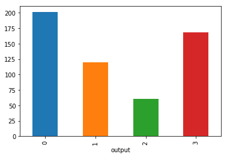

```python
# plot bar chart for the output column
                        data1.groupby('output').size().plot(kind='bar')
```

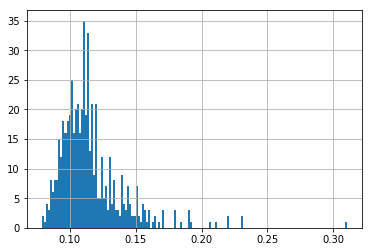

```python
# plot histogram for the t1 column
                        data1.t1.hist(bins=150)
```

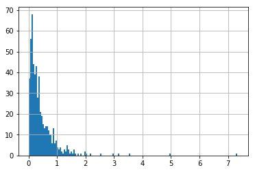

```python
# plot histogram for the h5 column
                        data1.h5.hist(bins=150)
```

```python
# remove outliers
                        from scipy import stats
                        data1 = data1[(np.abs(stats.zscore(data1.drop('Num', 1))) < 1.6).all(axis=1)]
```

```python
# check the data again after removing some outliers
                        data1.info()
```

```
<class 'pandas.core.frame.DataFrame'>
                            Int64Index: 326 entries, 4 to 548
                            Data columns (total 19 columns):
                            Num         326 non-null object
                            t1          326 non-null float64
                            t2          326 non-null float64
                            t4          326 non-null float64
                            t5          326 non-null float64
                            t           326 non-null float64
                            w           326 non-null float64
                            h1          326 non-null float64
                            h3          326 non-null float64
                            h4          326 non-null float64
                            h5          326 non-null float64
                            alpha       326 non-null float64
                            theta       326 non-null float64
                            Aa          326 non-null float64
                            Ab          326 non-null float64
                            pulse       326 non-null int64
                            source      326 non-null int64
                            pressure    326 non-null float64
                            output      326 non-null int64
                            dtypes: float64(15), int64(3), object(1)
                            memory usage: 50.9+ KB
```

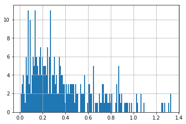

```python
# plot histogram for the h5 column again
                        data1.h5.hist(bins=150)
```

### 2) Create a new output binary variable and train-test split

```python
# create a new column named 'binary', 0 if output value is 0 and 1 if output value is 1, 2, or 3.
                    data1['binary'] = data1.apply(lambda row: 0 if row['output'] == 0 else 1, axis = 1)
```

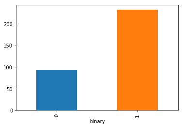

```python
data1.groupby('binary').size().plot(kind='bar')
```

```python
data1.head()
```

|  | Num | t1 | t2 | t4 | t5 | t | w | h1 | h3 | h4 | h5 | alpha | theta | Aa | Ab | pulse | source | pressure | output | binary |
| --- | --- | --- | --- | --- | --- | --- | --- | --- | --- | --- | --- | --- | --- | --- | --- | --- | --- | --- | --- | --- |
| 4 | 515026 | 0.106000 | 0.230000 | 0.360000 | 0.274000 | 0.636000 | 0.166000 | 7.828425 | 4.975650 | 2.260725 | 0.308100 | 71.228240 | 72.404355 | 9.454012 | 40.078069 | 93 | 160 | 7.828425 | 0 | 0 |
| 6 | 515030 | 0.093571 | 0.196429 | 0.304286 | 0.385714 | 0.690000 | 0.160000 | 13.224161 | 9.056411 | 4.649116 | 0.292607 | 79.958726 | 47.318490 | 14.818379 | 70.089951 | 87 | 160 | 13.224161 | 0 | 0 |
| 8 | 515034 | 0.092667 | 0.194000 | 0.301333 | 0.344000 | 0.646667 | 0.116667 | 9.584225 | 5.096150 | 3.165825 | 0.454800 | 76.421181 | 48.697194 | 10.265825 | 44.499412 | 93 | 160 | 9.584225 | 0 | 0 |
| 9 | 515035 | 0.149231 | 0.274615 | 0.403846 | 0.355385 | 0.754615 | 0.209231 | 7.707548 | 5.368038 | 2.344067 | 0.160673 | 64.289734 | 87.450206 | 13.379690 | 43.893339 | 85 | 160 | 7.707548 | 0 | 0 |
| 13 | 515042 | 0.102000 | 0.202667 | 0.310000 | 0.356667 | 0.666000 | 0.140000 | 12.674125 | 8.077175 | 4.869325 | 0.174000 | 78.609873 | 44.313243 | 15.259350 | 65.489975 | 96 | 160 | 12.674125 | 0 | 0 |

```python
# feature scaling, features are standardized to have zero mean and unit variance
                    feature_scale_cols = ['t1', 't2', 't4', 't5', 't', 'w', 'h1', 'h3', 'h4', 'h5', 'alpha', 'theta', 'Aa', 'Ab']

                    from sklearn import preprocessing
                    scaler = preprocessing.StandardScaler().fit(data1[feature_scale_cols])
                    data_scaler = scaler.transform(data1[feature_scale_cols])

                    data_scaler_df = pd.DataFrame(data=data_scaler, columns=feature_scale_cols, index=data1.index)
                    data1.drop(feature_scale_cols, axis=1, inplace=True)
                    data1 = pd.concat([data1, data_scaler_df], axis=1)
```

```python
data1.head()
```

|  | Num | pulse | source | pressure | output | binary | t1 | t2 | t4 | t5 | t | w | h1 | h3 | h4 | h5 | alpha | theta | Aa | Ab |
| --- | --- | --- | --- | --- | --- | --- | --- | --- | --- | --- | --- | --- | --- | --- | --- | --- | --- | --- | --- | --- |
| 4 | 515026 | 93 | 160 | 7.828425 | 0 | 0 | -0.131134 | 0.813622 | 1.128293 | -0.976056 | -0.381492 | 0.145886 | -0.642289 | -0.644181 | -0.926241 | -0.239332 | -0.327010 | 0.424665 | -0.843519 | -0.704562 |
| 6 | 515030 | 87 | 160 | 13.224161 | 0 | 0 | -1.049086 | -0.753130 | -0.540916 | 0.429901 | 0.193868 | -0.034480 | 1.210897 | 1.473108 | 1.160165 | -0.293002 | 1.232224 | -0.903749 | 0.456387 | 1.073744 |
| 8 | 515034 | 93 | 160 | 9.584225 | 0 | 0 | -1.115910 | -0.866469 | -0.629370 | -0.095085 | -0.267840 | -1.337127 | -0.039252 | -0.581660 | -0.135581 | 0.268855 | 0.600431 | -0.830740 | -0.646799 | -0.442582 |
| 9 | 515035 | 85 | 160 | 7.707548 | 0 | 0 | 3.061811 | 2.895786 | 2.441930 | 0.048194 | 0.882334 | 1.445449 | -0.683804 | -0.440591 | -0.853436 | -0.750038 | -1.566203 | 1.221413 | 0.107760 | -0.478494 |
| 13 | 515042 | 96 | 160 | 12.674125 | 0 | 0 | -0.426567 | -0.462003 | -0.369715 | 0.064329 | -0.061847 | -0.635702 | 1.021985 | 0.965035 | 1.352531 | -0.703872 | 0.991323 | -1.062891 | 0.563244 | 0.801179 |

```python
# create X (features) and y (response)
                    X = data1[['t1', 't2', 't4', 't5', 't', 'w', 'h1', 'h3', 'h4', 'h5', 'alpha', 'theta', 'Aa', 'Ab']]
                    y = data1['binary']
```

```python
# split X and y into cross-validation (75%) and testing (25%) data sets.
                    from sklearn.cross_validation import train_test_split
                    X_cv, X_test, y_cv, y_test = train_test_split(X, y, test_size=0.25)
```

### 3) Machine learning modeling

```python
from sklearn.cross_validation import cross_val_score
```

```python
# Random Forest
                    from sklearn.ensemble import RandomForestClassifier
                    clf1 = RandomForestClassifier()
                    RF_score = cross_val_score(clf1, X_cv, y_cv, cv=10, scoring='accuracy').mean()
                    RF_score
```

```
0.7655652173913043
```

```python
# Naive Bayes
                    from sklearn.naive_bayes import GaussianNB
                    clf2 = GaussianNB()
                    NB_score = cross_val_score(clf2, X_cv, y_cv, cv=10, scoring='accuracy').mean()
                    NB_score
```

```
0.7250652173913043
```

```python
# Logistic Regression
                    from sklearn.linear_model import LogisticRegression
                    clf3 = LogisticRegression()
                    LR_score = cross_val_score(clf3, X_cv, y_cv, cv=10, scoring='accuracy').mean()
                    LR_score
```

```
0.7987463768115941
```

### 4) Model evaluation

```python
# build the model using Logistic Regression
                    model = LogisticRegression()
                    model.fit(X_cv, y_cv)
                    y_pred = model.predict(X_test)
```

```
Confusion matrix, without normalization
                        [[54  3]
                        [15 10]]
                        Normalized confusion matrix
                        [[0.95 0.05]
                        [0.6  0.4 ]]
```

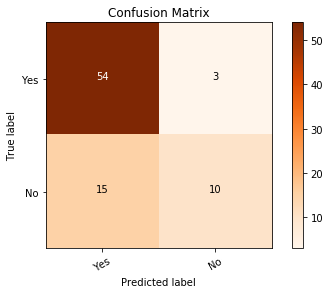

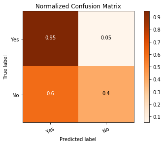

```python
# plot confusion matrix
                    from sklearn.metrics import confusion_matrix
                    import itertools

                    def plot_confusion_matrix(cm, classes,
                    normalize=False,
                    title='Confusion matrix',
                    cmap=plt.cm.Oranges):
                    """
                        This function prints and plots the confusion matrix.
                        Normalization can be applied by setting `normalize=True`.
                        """
                    if normalize:
                    cm = cm.astype('float') / cm.sum(axis=1)[:, np.newaxis]
                    print("Normalized confusion matrix")
                    else:
                    print('Confusion matrix, without normalization')

                    print(cm)

                    plt.imshow(cm, interpolation='nearest', cmap=cmap)
                    plt.title(title)
                    plt.colorbar()
                    tick_marks = np.arange(len(classes))
                    modify_class = ["Yes","No"]
                    plt.xticks(tick_marks, modify_class, rotation=30)
                    plt.yticks(tick_marks, modify_class)

                    thresh = cm.max() / 2.
                    for i, j in itertools.product(range(cm.shape[0]), range(cm.shape[1])):
                    plt.text(j, i, round(cm[i, j], 2),
                    horizontalalignment="center",
                    color="white" if cm[i, j] > thresh else "black")

                    plt.tight_layout()
                    plt.ylabel('True label')
                    plt.xlabel('Predicted label')

                    # Compute confusion matrix
                    class_names = [1, 0]
                    cnf_matrix = confusion_matrix(y_test, y_pred, labels=class_names)
                    np.set_printoptions(precision=2)

                    # Plot non-normalized confusion matrix
                    plt.figure()
                    plt.grid(b='off')
                    plot_confusion_matrix(cnf_matrix, classes=class_names,
                    title='Confusion Matrix')

                    # Plot normalized confusion matrix
                    plt.figure()
                    plot_confusion_matrix(cnf_matrix, classes=class_names, normalize=True,
                    title='Normalized Confusion Matrix')
                    plt.grid(b='off')
                    plt.show()
```

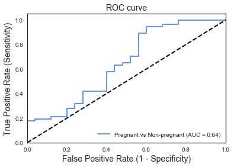

```python
# plot ROC curve
                    from sklearn import metrics
                    from sklearn.metrics import roc_curve, auc

                    # store the predicted probabilities for class 1
                    prob = model.predict_proba(X_test)[:, 1]

                    fpr1, tpr1, _ = roc_curve(y_test, prob)
                    roc_auc1 = auc(fpr1, tpr1)

                    plt.figure()
                    lw = 2
                    with plt.rc_context(sns.plotting_context("notebook", font_scale=1)):
                    sns.set_style(style='white')
                    plt.plot(fpr1, tpr1, color='cornflowerblue',
                    lw=lw, label='Pregnant vs Non-pregnant (AUC = %0.2f)' % roc_auc1)

                    plt.plot([0, 1], [0, 1], 'k--', lw=lw)
                    plt.xlim([0, 1.0])
                    plt.ylim([0, 1.05])
                    plt.title('ROC curve', fontsize=14)
                    plt.xlabel('False Positive Rate (1 - Specificity)', fontsize=14)
                    plt.ylabel('True Positive Rate (Sensitivity)', fontsize=14)
                    plt.legend(loc="lower right")
                    plt.show()
```